# NetNCP tutorial

This is a tutorial for the netNCP approach, presenting the main concepts and calculation steps based on a fictional, simple case study. It is meant as a demonstration for the paper by Neyret et al. Quantifying the impacts of socio-ecosystem change through expanded ecosystem multifunctionality (2026). Advances in Ecological Research.

```r
library(data.table)
library(knitr)
library(ggplot2)
library(cowplot)
library(colorspace)
library(terra)
library(tidyterra)
library(ggradar)
knitr::opts_chunk$set(tidy = 'formatR', collapse = TRUE, warning = FALSE, message = FALSE)
```

# Setting up the case study and preliminary analyses

The fictional area is a composed of 54% intensive pasture and 36% woodland, that is partially used as extensive sylvopasture. The remaining 10% is a swamp. Three stakeholder groups are considered: locals, farmers and foresters. Half the area is privately owned (red rectangle below), potentially restricting access to some stakeholder groups.

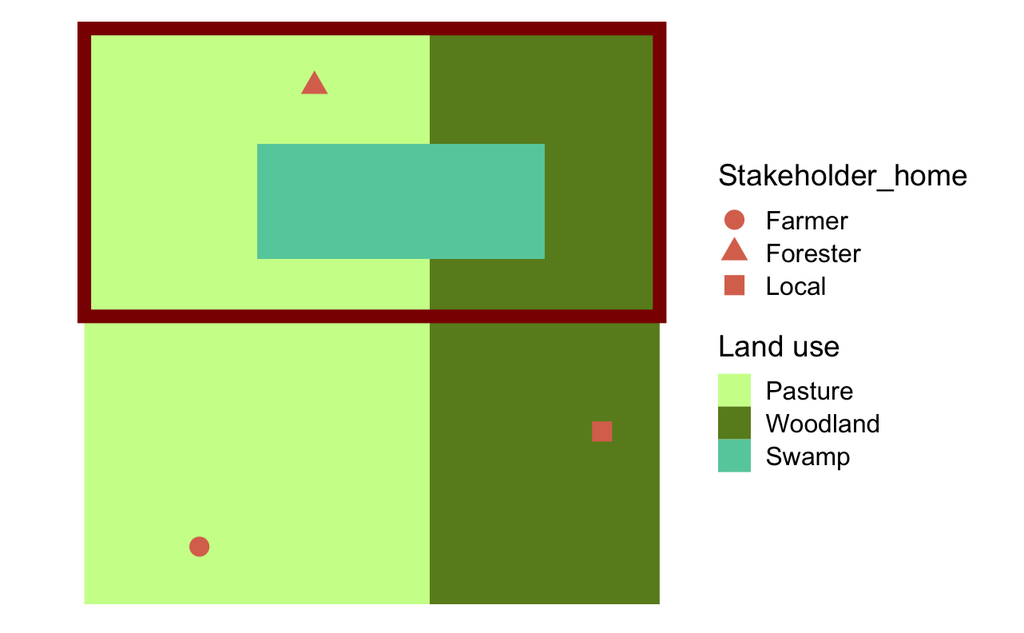

### NCP indicators and supply

We focus on four main NCP: climate change mitigation (estimated from carbon sequestration rates in soil and vegetation), livestock production (annual fodder productivity), aesthetic value (estimated from flower cover and vegetation structural diversity), and health risks (disease vectors).

```r
Supply_indicators = as.data.table(list(LU_type = c('Pasture', 'Woodland', 'Swamp'),
                                Climate_seq_soil = c(0.3, 0.4, -1), # C sequestration rates in soil, t.C/ha/yr
                                Climate_seq_veg = c(2, 3, 0),  # C sequestration rates in vegetation, t.C/ha/yr
                                Livestock_prod = c(13, 7, 0),  # Fodder productivity, ton/ha/yr
                                Aesthetic_flower = c(20, 40, 50),   # % of flower cover
                                Aesthetic_diversity = c(1, 6, 7),  # # of species present
                                Health_risk = c(0, 0, 20))) # Abundance of disease vectors

kable(Supply_indicators, caption = 'Average indicator values per forest type')
```

Average indicator values per forest type

| LU_type | Climate_seq_soil | Climate_seq_veg | Livestock_prod | Aesthetic_flower | Aesthetic_diversity | Health_risk |
| --- | --- | --- | --- | --- | --- | --- |
| Pasture | 0.3 | 2 | 13 | 20 | 1 | 0 |
| Woodland | 0.4 | 3 | 7 | 40 | 6 | 0 |
| Swamp | -1.0 | 0 | 0 | 50 | 7 | 20 |

### NCP priorities

All stakeholders groups were asked to distribute a maximum of 10 points to each NCP, representing their priority for the supply (or avoidance thereof) of the NCP. In practice, interviews should be conducted across multiple respondents; here only the average by group is shown.

Priority points per stakeholder group

| NCP | Farmers | Foresters | Locals |
| --- | --- | --- | --- |
| Climate | 2 | 5 | 1 |
| Livestock | 5 | 2 | 1 |
| Aesthetic | 2 | 1 | 2 |
| Health risk | 1 | 2 | 6 |

We need to obtain relative priority scores (scaled between 0 and 1) by scaling the priority to the total number of points given by each group. This is also converted to the long format to facilitate integration with the supply data.

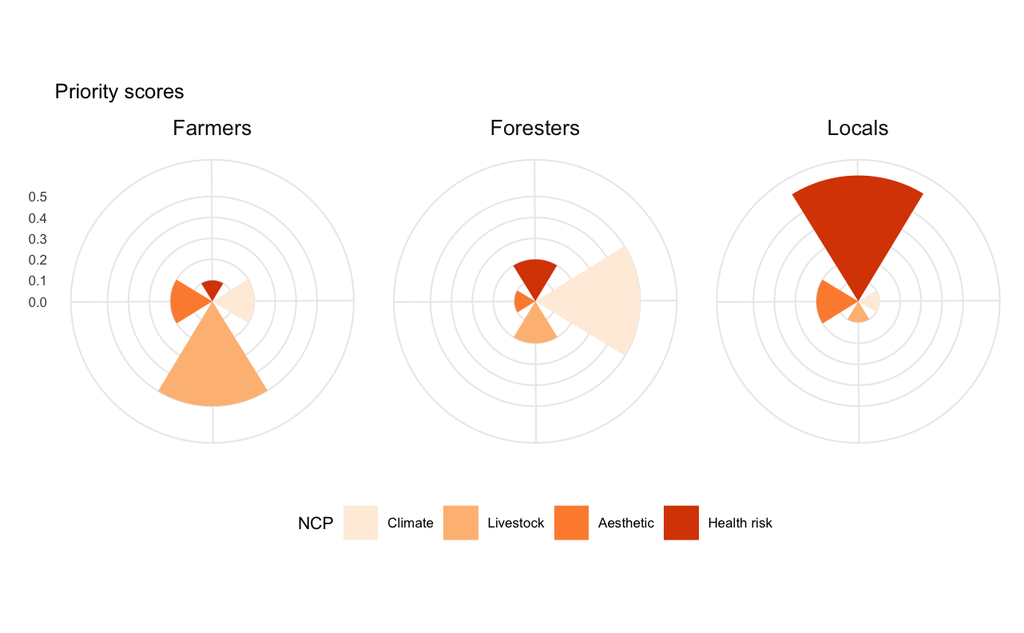

```r
Priority_relative = Priority_points[, list(NCP = NCP,
                                           Farmers = Farmers/(sum(Farmers)),
                                           Foresters = Foresters/(sum(Foresters)),
                                           Locals = Locals/(sum(Locals)))]

Priority_long = melt.data.table(Priority_relative, id.vars = 'NCP', variable.name = "Group", value.name = "Priority")

Priority_relative_plot = dcast(melt(Priority_relative, id.vars = "NCP", variable.name = 'Group'), Group ~ NCP)

Priority_long[, NCP := factor(NCP, levels = c('Climate','Livestock','Aesthetic', 'Health risk'))]
ggPriority = ggplot(Priority_long, aes(x = NCP, y = Priority, fill = NCP)) +
  geom_col(width = 0.7) +
  scale_fill_brewer(palette = "Oranges", name ='NCP', breaks = c('Climate','Livestock','Aesthetic', 'Health risk')) +
  coord_polar(start = 0.78) + facet_wrap(~Group) +
   scale_y_log10()+
  ylim(0,0.6) + theme_minimal(base_size = 8) + xlab('') + ylab('')+
   theme(axis.text.x=element_blank(), #remove x axis labels
        axis.ticks.x=element_blank(), #remove x axis ticks
    plot.background = element_rect(fill='transparent', color=NA), #transparent plot bg
    strip.text.x = element_text(size = 10),
    legend.position="bottom") + ggtitle('Priority scores')
ggPriority
```

## Supply-benefit/detriment relationships

Ideally, supply-benefit relationships should be deducted from quantitative or semi-quantitative surveys and adapted to individual stakeholder groups. Here we provide a function to create examples of SB relationships for standard shapes. If you use your own supply-benefit/detriments relationships, make sure the resulting benefits/detriments are scaled between 0 (no benefit/detriment) and 1 (maximum benefit) or -1 (maximum detriment).

```r
# This function takes as input the observed supply, the name of the single NCP, the expected shape of the SB relationship, the theoretical minimum and maximum supply of the single NCP, and if needed the threshold
SB_relationship = function(supply_obs, names = NA, shape, supply_min, supply_max, threshold = NA){
  supply_was_na = FALSE
          if (all(is.na(supply_obs))){ # If no supply is provided, a sequence is generated between the min and max supply
            supply_obs = seq(supply_min, supply_max, length.out = 50)
              supply_was_na = TRUE
          }
            if ( (min(supply_obs) < supply_min | max(supply_obs) > supply_max)) {
              print("Warning: S should be in range (between min and max)")
            }

           if (!is.na(threshold)){
             if (threshold <= supply_min | threshold >= supply_max ) {
              print(
                "Warning: the threshold should be higher than the minimum and lower than the maximum supply"
              )}}
            if (shape == "linear_benefits") { # E.g. aesthetics follow a linear positive SB relationship
              benefit_obs = (supply_obs - supply_min)/(supply_max - supply_min)
            }
            if (shape == "linear_detriments") { # E.g. health risks follow a linear negative SB relationship
              benefit_obs = -(supply_obs - supply_min)/(supply_max - supply_min)
            }
            if (shape == "threshold_cubic_benefits") {# Production needs to reach a threshold before becoming profitable, then increasing return. Eg: timber production
               benefit_obs = ifelse(supply_obs < threshold, 0, (supply_obs^3 - supply_min^3)/(supply_max^3 - supply_min^3))
            }
            if (shape == "detriments_threshold_benefits") {# E.g. carbon sequestration
               benefit_obs = ifelse(supply_obs < threshold, (supply_obs - threshold) / (supply_max - threshold), (supply_obs - threshold)/(supply_max- threshold))
            }
             return(list(benefit_obs = benefit_obs))
 }

# This function applies SB relationship to a data table, taking as input the data table, NCP names as well as min, max and threshold values for each NCP
apply_SB = function(DATA, ncp_names, supply_min, supply_max, shapes, thresholds = NA){
 for (ncp in ncp_names){
   DATA[NCP == ncp,
              Benefits := SB_relationship(supply_obs = NCP_supply_realised, supply_min = supply_min[ncp], supply_max = supply_max[ncp],
                                          shape = shapes[ncp], threshold = thresholds[ncp])]
 }
  return(DATA)
}

# This function plot the SB relationships based on given supply values
plot_SB = function(DATA, ncp_names, supply_min, supply_max, shapes, thresholds, breaks = 100){
  # Create sequential data
   SBdata = data.table(NCP = rep(ncp_names, each = breaks))
   SBdata = SBdata[, NCP_supply_realised := seq(from = supply_min[NCP], to = supply_max[NCP], length.out = breaks), by = NCP]

   apply_SB(SBdata, ncp_names, supply_min, supply_max, shapes, thresholds)
   SBdata[Benefits >= 0, c('ribbon_max', 'ribbon_min') := list(Benefits, 0)]
   SBdata[Benefits < 0,  c('ribbon_max', 'ribbon_min') := list(0, Benefits)]

      SBplot = ggplot(SBdata, aes(x = NCP_supply_realised, y = Benefits, fill = Benefits>0, ymax = ribbon_max, ymin = ribbon_min)) + facet_wrap(~NCP, , scales = "free") +
              geom_ribbon(alpha = 0.3) +
        scale_fill_manual(values = c('#FDAE61', '#ABDDA4'), labels = c('Detriments', 'Benefits'), name = '')+
              xlab('Supply') + ylab('Benefit') + theme_bw()

     # if supply data is provided, calculate corresponding benefits
  if (!is.null(DATA) & !all(is.na(DATA$NCP_supply_realised))){
  apply_SB(DATA, ncp_names, supply_min, supply_max, shapes, thresholds)

  SBplot = SBplot +
    geom_segment(data = DATA, aes(x = -Inf, xend = NCP_supply_realised, yend = Benefits, y = Benefits),  inherit.aes = F) +
    geom_segment(data = DATA, aes(x = NCP_supply_realised, xend = NCP_supply_realised, yend = Benefits, y = -Inf), inherit.aes = F) +xlab('Supply') + ylab('Detriments   -    Benefits')  }
 return(SBplot)
}

# This function scales values between 0 (min) and 1 (max)
scale01 = function(x){
  y = x/abs(max(x))
}
```

# Calculation of netNCP

### Step 1. NCP supply and access

The first step is to convert the indicator values into (potential) supply estimates. The exact procedure depends on the NCP and indicators. Here, the climate change mitigation is measured as the sum of carbon sequestration rates in soils and trees; livestock production as the fodder productivity (sole indicator); and aesthetic value and health risks as the average of their respective components, after scaling them between 0 and 1.

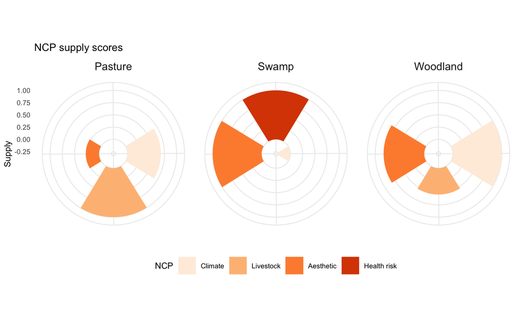

```r
Supply_NCP = Supply_indicators[, list(LU_type = LU_type,
                                      Climate = scale01(Climate_seq_soil + Climate_seq_veg),
                                      Livestock = scale01(Livestock_prod),
                                      Aesthetic = (scale01(Aesthetic_flower) + scale01(Aesthetic_diversity))/2,
                                      `Health risk` =  scale01(Health_risk))]

Supply_NCP_mean = melt.data.table(Supply_NCP, id.vars = 'LU_type', value.name = 'NCP_supply_potential', variable.name = 'NCP')
Supply_NCP_mean[, NCP := factor(NCP, levels = c('Climate','Livestock','Aesthetic', 'Health risk'))]

ggSupply = ggplot(Supply_NCP_mean, aes(x = NCP, y = NCP_supply_potential, fill = NCP)) +
  geom_col(width = 0.7) +
  scale_fill_brewer(palette = "Oranges", name ='NCP', breaks = c('Climate','Livestock','Aesthetic', 'Health risk')) +
  coord_polar(start = 0.78) + facet_wrap(~LU_type) +
   theme_minimal(base_size = 8) + xlab('') + ylab('Supply')+
   theme(axis.text.x=element_blank(), #remove x axis labels
        axis.ticks.x=element_blank(), #remove x axis ticks
    plot.background = element_rect(fill='transparent', color=NA), #transparent plot bg
    strip.text.x = element_text(size = 10),
    legend.position="bottom") + ggtitle('NCP supply scores')
ggSupply
```

We combine this with priority data.

```r
# Add stakeholders in
NCP_demand_priority = merge.data.table(Supply_NCP_mean, Priority_long, by = 'NCP', allow.cartesian=TRUE)
```

### Scenarios description

We now build our different scenarios of multifunctionality. For each scenario the situation diverge from the baseline scenario by only one element, specified below; the other parameters remain the same.

In *the baseline situation*, the area is composed of 54% pastures, 36% woodland, and 10% swamp.

In *scenario 2*, the analysis accounts for access restriction. Half of the area, including the swamp, is privately owned, which means local residents cannot access the NCP supplied there, except for carbon sequestration, which does not require access. Foresters and farmers can access the whole area.

In *scenario 3*, subsidies mean that benefits for a given livestock production level increase; the threshold at which the production becomes economically viable decreases.

In *scenario 4*, stakeholder priorities change, and all stakeholders’ priorities for climate regulation increase.

In *scenario 5*, the assessment fails to account for the detriments associated with disease vector occurrence.

In *scenario 6*, the analysis accounts for the spatial dimension of supply-benefit relationships: here benefits from aesthetic value are assume to decrease with distance from each stakehodler’s residence.

#### Baseline situation

```r
#### Creating a large data table with information on all scenarios
Scenarios = data.table(expand.grid(Group = c('Farmers', 'Foresters', 'Locals'),
                                   Scenarios = seq(from = 0, to = 6),
                                   LU_type = c('Pasture', 'Woodland', 'Swamp')))

## Setting the proportion of each land use in the landscape.
# For most scenarios this is equal to the baseline situation
prop_landscape_0 = table(landscape)/100
Scenarios[Scenarios != 1,
          Prop_landscape := ifelse(LU_type == 'Pasture', prop_landscape_0['Pasture'],
                                                  ifelse(LU_type == 'Woodland', prop_landscape_0['Woodland'],
                                                                          prop_landscape_0['Swamp'])), by = Group]
```

#### Adaptation of land use and access for scenarios 1 and 2

```r
# For scenario 1, a large part of the pastures are reforested
Scenarios[Scenarios == 1, Prop_landscape := ifelse(LU_type == 'Pasture', 0.2,
                                                      ifelse(LU_type == 'Woodland', 0.7,
                                                                               0.1)), by = Group]

## Setting the accessible proportion of each land use in the landscape,
# In most scenarios there is full access
Scenarios[, Prop_landscape_accessible := Prop_landscape]

# In scenario 2 locals have no access to the swamp and half the remaining area
Scenarios[Scenarios ==2  & Group == 'Locals',
          Prop_landscape_accessible := ifelse(LU_type == 'Swamp', 0,
                                           Prop_landscape/2)]
```

We calculate the realised NCP supply, as the total landscape supply (baseline supplied weighted by proportion of each land use) for climate mitigation, restricted to what is accessible for other NCP. We then sum the overall NCP supply in the whole landscape, across land uses.

```r
Supply_access_NCP = merge.data.table(Supply_NCP_mean, Scenarios, by = c('LU_type'), allow.cartesian=TRUE)

Supply_access_NCP[NCP == 'Climate', NCP_supply_realised := NCP_supply_potential*Prop_landscape]
Supply_access_NCP[NCP != 'Climate', NCP_supply_realised := NCP_supply_potential*Prop_landscape_accessible]


Supply_realised_landscape = Supply_access_NCP[, list(NCP_supply_realised = sum(NCP_supply_realised)), by = list(NCP, Group, Scenarios)]
```

### Step 2 and 3. Supply-benefit relationship

#### Baseline situation

The realised supply scores can then be converted into benefits through the supply-benefit relationship. This need to be done independently for each service. We obtain final benefits and detriment scores.

```r
# Here we define the parameters to apply SB/D relationships: determine minimal and maximal theoretical values
ncp_names = c('Climate','Livestock', 'Aesthetic', 'Health risk')
supply_min = c(Climate = -1, Livestock = 0, Aesthetic = 0, `Health risk` = 0)
supply_max = c(Climate = 1, Livestock = 1, Aesthetic = 1, `Health risk` = 1)
shapes =     c(Climate = 'detriments_threshold_benefits', Livestock = 'threshold_cubic_benefits', Aesthetic = 'linear_benefits', `Health risk` = 'linear_detriments')
thresholds = c(Climate = 0, Livestock = 0.35, Aesthetic = NA, `Health risk` = NA)

# Apply the function using these parameters. This adds a column to the Supply_realised_landscape data table.
apply_SB(Supply_realised_landscape, ncp_names, supply_min, supply_max, shapes, thresholds)
```

```r
plotSB = plot_SB(Supply_NCP_mean[,  NCP_supply_realised := NCP_supply_potential], ncp_names, supply_min, supply_max, shapes, thresholds) +
    geom_segment(data = Supply_NCP_mean, aes(x = -Inf, xend = NCP_supply_realised, yend = Benefits, y = Benefits), color = 'grey30', inherit.aes = F) +
    geom_segment(data = Supply_NCP_mean, aes(x = NCP_supply_realised, xend = NCP_supply_realised, yend = Benefits, y = -Inf),color = 'grey30', inherit.aes = F) +
   theme_classic(base_size = 8) + ylim(-1, 1)+
   theme(
        axis.ticks.x=element_blank(), #remove x axis ticks
        panel.grid.minor = element_blank(),
        plot.background = element_rect(fill='transparent', color=NA), #transparent plot bg
        axis.ticks.y=element_blank(),  #remove y axis ticks
        strip.text.x = element_text(size = 10, color = 'black'),
    strip.background = element_rect(colour="NA", fill="NA"),
    legend.position="bottom") + geom_hline(yintercept = 0, size = 0.1)+ geom_vline(xintercept = 0, size = 0.1)+ ggtitle('Supply-benefit relationships')

plotSB
```

[output not shown]

#### Adaptation of SB relationship for scenario 3

In scenario 3, subsidies increase the benefits from livestock production

```r
Supply_realised_landscape[Scenarios == 3 & NCP == 'Livestock', Benefits := Benefits + 0.2]
```

#### Adaptation of SB relationship for scenario 6

In scenario 6, the spatial dimension of SB relationship is added. We need a slightly different approach that takes into account where each stakeholder live and a distance-decay function for benefits. Specific decisions on how to standardize distances, resulting weighted benefits, etc should be adapted depending on the context of each study; this is only a theoretical example.

```r
# First we convert the land use map into supply values
supply_aesthetics = Supply_NCP$Aesthetic
names(supply_aesthetics) = Supply_NCP$LU_type
landscape_supply = matrix(supply_aesthetics[landscape], nrow = 10, byrow = F)

# then into benefit values (no change here because it is a linear transformation)
landscape_benefit = SB_relationship(landscape_supply, supply_min = supply_min['Aesthetic'],supply_max = supply_max['Aesthetic'], shape = shapes['Aesthetic'])[[1]]
landscape_benefit = rast(landscape_benefit,  crs="+proj=longlat +datum=WGS84")

# then we downweight benefits with increasing distance from people's homes
landscape_r = rast(landscape, crs="+proj=longlat +datum=WGS84") # Adding crs to measure distance; scale not representative
homes_v = vect(homes, 'points', geom = c('x', 'y'))
crs(homes_v) = crs="+proj=longlat +datum=WGS84"

dist_farm  <- distance(x = landscape_r, y = homes_v[1,])
dist_fore  <- distance(x = landscape_r, y = homes_v[2,])
dist_local <- distance(x = landscape_r, y = homes_v[3,])

dist_farm  <- 1 - (dist_farm / max(values(dist_farm )))
dist_fore  <- 1 - (dist_fore / max(values(dist_fore )))
dist_local <- 1 - (dist_local/ max(values(dist_local)))

landscape_benefit_farm = landscape_benefit * dist_farm
landscape_benefit_fore = landscape_benefit * dist_fore
landscape_benefit_local = landscape_benefit * dist_local

list_plots = c(dist_farm, dist_fore, dist_local,
               landscape_benefit_farm, landscape_benefit_fore, landscape_benefit_local)
names(list_plots) = c('Distance decay (farmers)','Distance decay (foresters)','Distance decay (locals)',
                      'Resulting benefits (farmers)','Resulting benefits (foresters)','Resulting benefits (locals)')
plot(list_plots)

# The supply is the mean of the values across the landscape
Supply_realised_landscape[NCP == "Aesthetic" & Scenarios == 6 & Group == "Farmers", Benefits := mean(values(landscape_benefit_farm))]
Supply_realised_landscape[NCP == "Aesthetic" & Scenarios == 6 & Group == "Foresters", Benefits := mean(values(landscape_benefit_fore))]
Supply_realised_landscape[NCP == "Aesthetic" & Scenarios == 6 & Group == "Locals", Benefits := mean(values(landscape_benefit_local))]
```

[output not shown]

### Step 4. Integration of stakeholder priority scores into weighted NCP scores

Now we merge both datasets and calculate weighted benefit scores as benefits x priority.

```r
Supply_access_priority = merge.data.table(Priority_long, Supply_realised_landscape, by = c('NCP','Group' ))
```

#### Changing priorities dor scenarios 4 and 5

```r
## Scenario 4: all stakeholders prioritise climate regulation more highly
Supply_access_priority[Scenarios == 4 & NCP == 'Climate', Priority := Priority+0.1]
Supply_access_priority[Scenarios == 4, Priority := Priority/sum(Priority), by = Group]

## Scenario 5: detriments from disease occurence is disregarded
Supply_access_priority[Scenarios == 5 & NCP == 'Health risk', Priority := 0]
Supply_access_priority[Scenarios == 5, Priority := Priority/sum(Priority), by = Group]

Supply_access_priority[, Weighted_scores := Benefits * Priority]
```

### Step 5. Calculation of netNCP

Finally we calculate netNCP for each stakeholder group and the whole community

```r
netNCP_bygroup = Supply_access_priority[, list(netNCP = sum(Weighted_scores)), by = list(Group, Scenarios)]

#netNCP_overall = netNCP_bygroup[, list(netNCP = mean(netNCP),
#                                       equity = 1/sd(netNCP)), by = Scenarios]

ggnetNCP0 =ggplot(Supply_access_priority[Scenarios == 0, ], aes(x = Group, y = Weighted_scores, fill = NCP)) +
 # ggtitle('NetNCP across scenarios and stakeholder groups (full red lines)') +
  geom_col(width = 0.8) +
  scale_fill_brewer(palette = "Oranges", name ='NCP', breaks = c('Climate','Livestock','Aesthetic', 'Health risk')) +
  facet_wrap(~Scenarios, nrow = 1) +
  theme_minimal(base_size = 8) + xlab('') + ylab('netNCP')+
   theme(axis.text.x=element_text(angle = 45, vjust = 0.5),
         axis.ticks.x=element_blank(), #remove x axis ticks
         plot.background = element_rect(fill='transparent', color=NA), #transparent plot bg
    legend.position="none",
    axis.line = element_line(colour = "black", linewidth = 0.5),
    panel.spacing = unit(1.5, "lines"),
   # strip.text.x = element_text(size = 10, color = NA),
    strip.background = element_rect(colour="NA", fill="NA")) +
     geom_errorbar(data = netNCP_bygroup[Scenarios == 0, ], aes(x = Group, y=netNCP,ymin=netNCP,ymax=netNCP), color = 'darkred', size = 0.4 , inherit.aes = FALSE) +
  # geom_hline(data = netNCP_overall, aes(yintercept = netNCP), color = 'darkred', size = 0.7, linetype = "longdash") +
  geom_hline(aes(yintercept = 0), color = 'black', size = 0.3)


ggnetNCP = ggplot(Supply_access_priority[Scenarios != 0,], aes(x = Group, y = Weighted_scores, fill = NCP)) +
  ggtitle('NetNCP across scenarios and stakeholder groups (full red lines)') +
  geom_col(width = 0.8) +
  scale_fill_brewer(palette = "Oranges", name ='NCP', breaks = c('Climate','Livestock','Aesthetic', 'Health risk')) +
  facet_wrap(~Scenarios, nrow = 1) +
  theme_minimal(base_size = 8) + xlab('') + ylab('netNCP')+
   theme(axis.text.x=element_text(angle = 45, vjust = 0.5),
         axis.ticks.x=element_blank(), #remove x axis ticks
         plot.background = element_rect(fill='transparent', color=NA), #transparent plot bg
    legend.position="bottom",
    axis.line = element_line(colour = "black", linewidth = 0.5),
    panel.spacing = unit(1.5, "lines"),
   # strip.text.x = element_text(size = 10, color = NA),
    strip.background = element_rect(colour="NA", fill="NA")) +
     geom_errorbar(data = netNCP_bygroup[Scenarios != 0, ], aes(x = Group, y=netNCP,ymin=netNCP,ymax=netNCP), color = 'darkred', size = 0.4 , inherit.aes = FALSE) +
  # geom_hline(data = netNCP_overall, aes(yintercept = netNCP), color = 'darkred', size = 0.7, linetype = "longdash") +
  geom_hline(aes(yintercept = 0), color = 'black', size = 0.3)


ggsave(plot = ggnetNCP0+ ggtitle('') + theme(legend.position = 'none'), paste( '/Users/neyretma/Documents/Senckenberg/Framework/AER/ggnetNCP0.png', sep = ''), width = 1, height = 1.5)

ggsave(plot = ggnetNCP+ ggtitle('') + theme(legend.position = 'none'), paste( '/Users/neyretma/Documents/Senckenberg/Framework/AER/ggnetNCP.png', sep = ''), width = 6, height = 1.5)

ggnetNCP
```

[output not shown]